# {shapviz} demo

With Miami House Prices

Michael Mayer

January 11, 2024

## Introduction

Welcome to this compact {shapviz} demo. We will model logarithmic house prices by typical features using XGBoost and study the model via SHAP.

## The data

We will use 14k rows of miami house price data prepared by Prof. Steve Bourassa. It is shipped with {shapviz}.

```r
knitr::opts_chunk$set(
  fig.width = 6, fig.height = 5, comment = "", message = FALSE, warning = FALSE
)
```

```r
library(xgboost)
library(ggplot2)
library(patchwork)
library(shapviz)

# Log transforms and feature selection
df <- miami |>
  transform(
    log_price = log(SALE_PRC),
    log_living = log(TOT_LVG_AREA),
    log_land = log(LND_SQFOOT),
    center_dist = CNTR_DIST / 1000
  )
xvar <- c(
  "center_dist", "log_living", "log_land", "structure_quality", "age", "month_sold"
)
df <- df[c("log_price", xvar)]

head(df)
```

|  | log_price | center_dist | log_living | log_land | structure_quality | age | month_sold |
| --- | --- | --- | --- | --- | --- | --- | --- |
| 0 | 12.99453 | 42.8153 | 7.469084 | 9.145802 | 4 | 67 | 8 |
| 1 | 12.76283 | 43.5049 | 7.447168 | 9.145802 | 4 | 63 | 9 |
| 2 | 13.59237 | 43.5304 | 7.730175 | 9.145802 | 4 | 61 | 2 |
| 3 | 13.80344 | 43.7975 | 7.629490 | 9.429476 | 4 | 63 | 9 |
| 4 | 13.53447 | 43.5997 | 7.428927 | 9.457200 | 4 | 42 | 7 |
| 5 | 13.35348 | 43.1351 | 7.333676 | 9.200290 | 4 | 41 | 2 |

```r
summary(df)
```

```
   log_price      center_dist        log_living       log_land
 Min.   :11.18   Min.   :  3.826   Min.   :6.750   Min.   : 7.129
 1st Qu.:12.37   1st Qu.: 42.823   1st Qu.:7.293   1st Qu.: 8.594
 Median :12.64   Median : 65.852   Median :7.538   Median : 8.923
 Mean   :12.71   Mean   : 68.490   Mean   :7.560   Mean   : 8.923
 3rd Qu.:12.97   3rd Qu.: 89.358   3rd Qu.:7.812   3rd Qu.: 9.119
 Max.   :14.79   Max.   :159.976   Max.   :8.746   Max.   :10.952
 structure_quality      age          month_sold
 Min.   :1.000     Min.   : 0.00   Min.   : 1.000
 1st Qu.:2.000     1st Qu.:14.00   1st Qu.: 4.000
 Median :4.000     Median :26.00   Median : 7.000
 Mean   :3.514     Mean   :30.67   Mean   : 6.656
 3rd Qu.:4.000     3rd Qu.:46.00   3rd Qu.: 9.000
 Max.   :5.000     Max.   :96.00   Max.   :12.000
```

## XGBoost model

```r
set.seed(1)
ix <- sample(nrow(df), 0.8 * nrow(df))
X_train <- data.matrix(df[ix, xvar])
X_valid <- data.matrix(df[-ix, xvar])

dtrain <- xgb.DMatrix(X_train, label = df$log_price[ix])
dvalid <- xgb.DMatrix(X_valid, label = df$log_price[-ix])
```

### Fit

```r
params <- list(
  learning_rate = 0.05,
  objective = "reg:squarederror",
  max_depth = 6,
  reg_alpha = 2,
  reg_lambda = 0
)

fit_xgb <- xgb.train(
  params = params,
  data = dtrain,
  watchlist = list(valid = dvalid),
  early_stopping_rounds = 20,
  nrounds = 1000,
  callbacks = list(cb.print.evaluation(period = 100))
)
```

[output not shown]

## SHAP analysis

We use 1000 rows from the training data to describe the model. Note that the training indices have been shuffled during train/test split, so that we are indeed using a random sample here.

### Make “shapviz” object

For an XGBoost model, `shapviz()` internally calls `predict(fit_xgb, X_pred, predcontrib = TRUE)` to have access to the native TreeSHAP implementation in XGBoost. Note that the XGBoost method of `shapviz()` uses `X = X_pred` by default. `X` could be overwritten to contain factor variables.

```r
X_explain <- X_train[1:1000, ]
shap_xgb <- shapviz(fit_xgb, X_pred = X_explain)
shap_xgb
```

```
'shapviz' object representing 1000 x 6 SHAP matrix
```

```r
head(shap_xgb$X, 2)
```

|  | center_dist | log_living | log_land | structure_quality | age | month_sold |
| --- | --- | --- | --- | --- | --- | --- |
| 1016 | 56.3412 | 7.492203 | 9.460321 | 4 | 0 | 5 |
| 8003 | 97.3174 | 8.094073 | 9.472705 | 4 | 28 | 6 |

```r
head(shap_xgb$S, 2)
```

```
     center_dist log_living   log_land structure_quality          age
[1,]  0.05388245 -0.1592027 0.05005766       0.025898742  0.035079595
[2,] -0.23489885  0.3555668 0.06573964       0.001576288 -0.006410511
       month_sold
[1,] -0.008768919
[2,] -0.002892996
```

### Importance plots

Note that the plots are “ggplots” and can be modified accordingly.

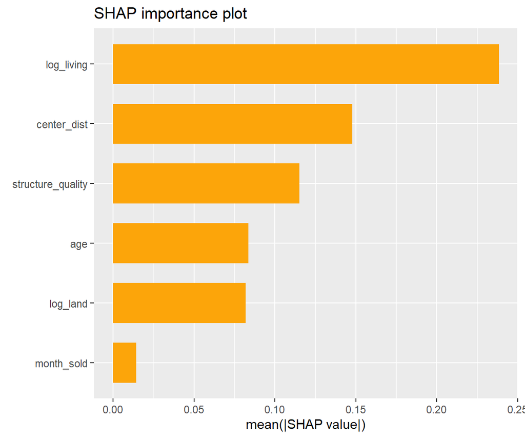

```r
sv_importance(shap_xgb) +
  ggtitle("SHAP importance plot")
```

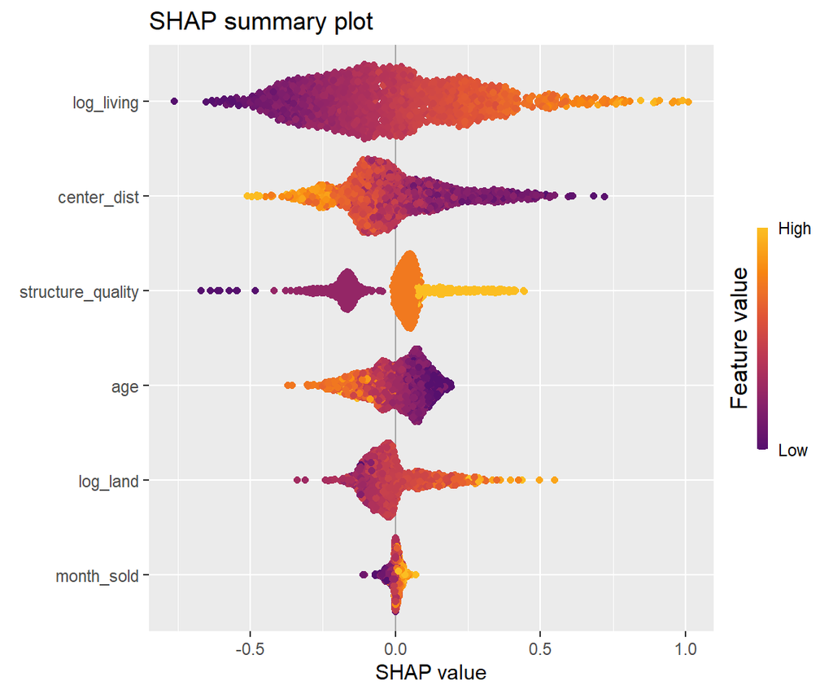

```r
sv_importance(shap_xgb, kind = "bee") +
  ggtitle("SHAP summary plot")
```

### Dependence plots

Multiple plots are glued together via {patchwork}. This allows different x and color scales. By default, the color scale is automatically chosen by a heuristic.

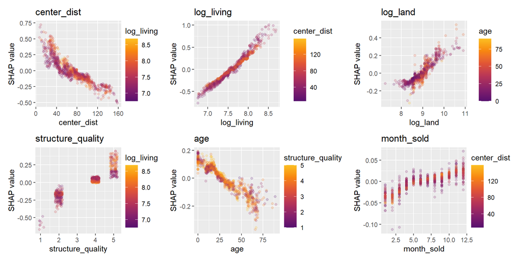

```r
sv_dependence(shap_xgb, v = xvar, alpha = 0.2)
```

### Individual predictions

We can also visualize decompositions of single observations via waterfall plot or force plot.

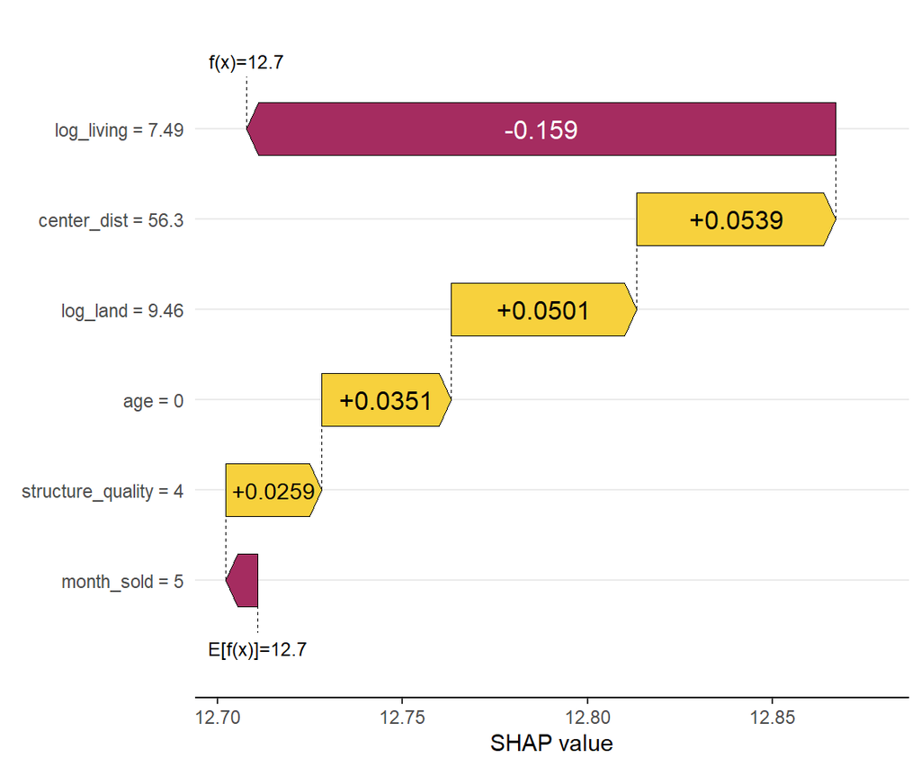

```r
sv_waterfall(shap_xgb, row_id = 1)
```

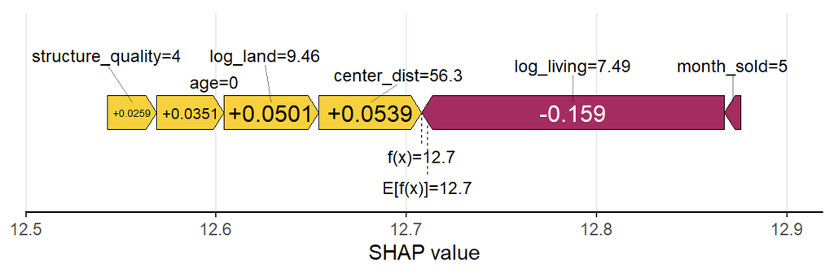

```r
sv_force(shap_xgb, row_id = 1)
```

### Some syntactic sugar

Different operators work on “shapviz” objects, e.g.,

- subset rows and/or columns via `[`,
- splitting,
- unsplitting via `+` or `rbind()`,
- `dim()`, `head()`, `nrow()`, `colnames()` etc.

```r
dim(shap_xgb)
```

```
[1] 1000    6
```

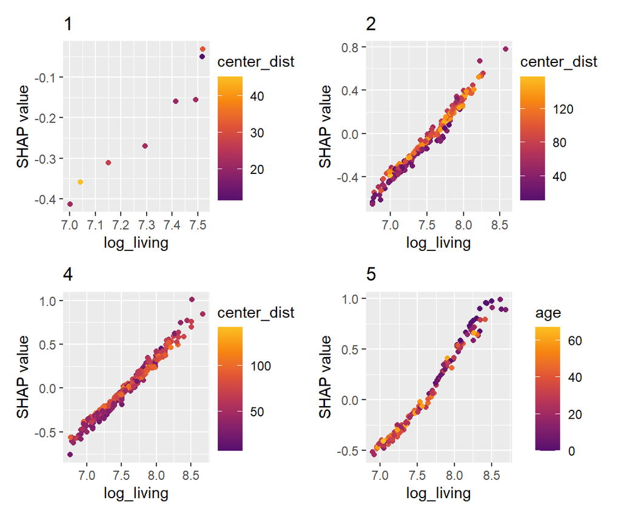

```r
# Split by "structure_quality"
f <- shap_xgb$X$structure_quality
sv_dependence(split(shap_xgb, f), v = "log_living")
```

## Linear model

We can use {kernelshap} to look at similar plots of any model, e.g., a complex linear model with natural cubic splines and interactions.

### Fit

```r
library(splines)
library(kernelshap)

fit_lm <- lm(
  log_price ~ ns(center_dist, 5) + ns(log_living, 5) * (center_dist < 65) + log_land +
              factor(structure_quality) + ns(age, 5) + ns(month_sold, 3),
  data = df,
  subset = ix
)
```

### SHAP analysis

The model is not tree-based, and we have only six features. Thus, we use exact permutation SHAP (exact only with respect to the selected ‘background’ data).

Note that a “shapviz” object can be easily saved as rds or RData file. It contains all information required to build all plots.

Further note that we use {patchwork}’s `&` operator to set the same `ylim` to each dependence plot. An equal y-scale immediately gives a good impression on the effect strenght of the features.

```r
df_explain <- as.data.frame(X_explain)

# Set to TRUE to recalculate permutation SHAP values
if (FALSE) {
  system.time(  # 45 seconds
    ks <- permshap(fit_lm, X = df_explain, bg_X = df_explain[1:200, ])
  )
  shap_lm <- shapviz(ks)
  saveRDS(shap_lm, file = "shap_lm.rds")
} else {
  shap_lm <- readRDS("shap_lm.rds")
}
```

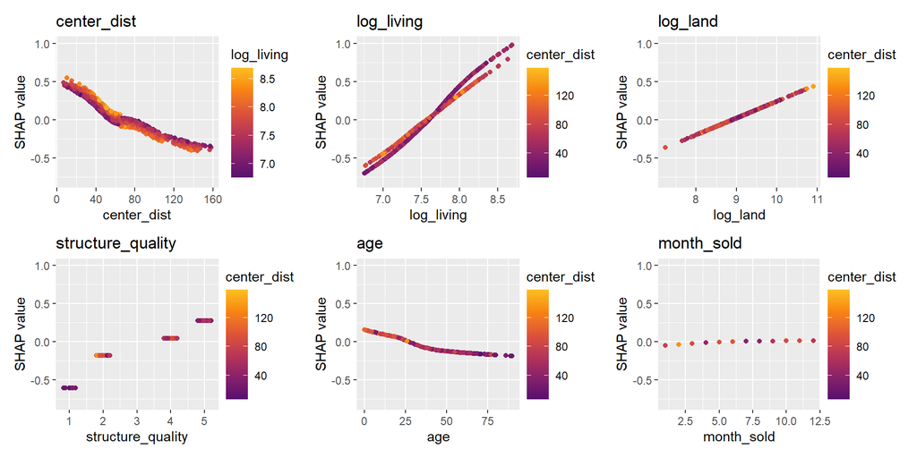

```r
sv_dependence(shap_lm, v = xvar) &
  ylim(-0.8, 1)
```

## Bind objects

Multiple “shapviz” objects can be glued together to an “mshapviz” objects via `c()`. Also multi-output models or `split()` produce “mshapviz” objects.

```r
mshap <- c(xgb = shap_xgb, lm = shap_lm)
mshap
```

```
'mshapviz' object representing 2 'shapviz' objects:
   'xgb': 1000 x 6 SHAP matrix
   'lm': 1000 x 6 SHAP matrix
```

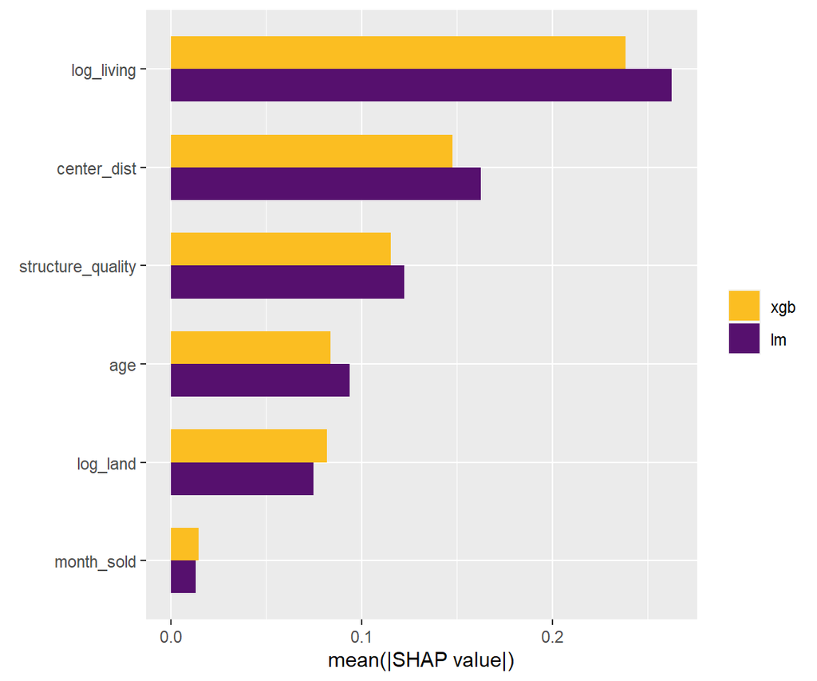

```r
sv_importance(mshap)
```

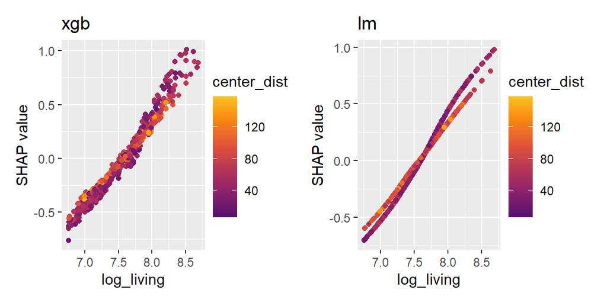

```r
sv_dependence(mshap, v = "log_living")
```